# Exercise: Predict Ad Click Probability (Logistic Regression)

Davide Proserpio

2026-10-19

**What we are doing.** An advertiser pays every time its ad is shown, but earns only when someone clicks. If we can predict **which impressions are likely to turn into a click**, the ad can go to the right people, in the right spot on the page, and less money is wasted. In this exercise you take 5,000 past ad impressions and run the full classifier recipe from class on them: split the data, fit a logit, turn its probabilities into yes/no calls, grade the calls with the confusion matrix (accuracy, precision, recall, F1), draw the ROC curve, and read the model through odds ratios. The outcome is `click`: 1 if the user clicked the ad, 0 if not.

# 1 Load Data & Explore Baseline Click Rate

```r
# Load the ad-click data (one row per impression) from CSV into a data.frame
df <- fread("ad_click_data.csv")

# Inspect the first few rows and summary statistics.
# Quick peek at the first rows to sanity-check columns and types
head(df)
```

```
##    click  device ad_position user_segment pages_viewed time_on_site topic_match
##    <int>  <char>      <char>       <char>        <int>        <int>       <int>
## 1:     0  mobile         top    returning            6           67           0
## 2:     1 desktop      bottom    returning            7          146           0
## 3:     0  mobile      middle          new            4           82           0
## 4:     0 desktop      middle    returning            1           37           1
## 5:     1 desktop         top    returning            3           95           1
## 6:     0  mobile         top    returning            2           89           0
##    past_ctr_hi
##          <int>
## 1:           0
## 2:           1
## 3:           0
## 4:           0
## 5:           0
## 6:           0
```

```r
# Summary stats: distribution of numeric vars and levels of factors
summary(df)
```

```
##      click              device        ad_position      user_segment
##  Min.   :0.0000   Length   :5000   Length   :5000   Length   :5000
##  1st Qu.:0.0000   N.unique :   2   N.unique :   3   N.unique :   2
##  Median :0.0000   N.blank  :   0   N.blank  :   0   N.blank  :   0
##  Mean   :0.3178   Min.nchar:   6   Min.nchar:   3   Min.nchar:   3
##  3rd Qu.:1.0000   Max.nchar:   7   Max.nchar:   6   Max.nchar:   9
##  Max.   :1.0000
##   pages_viewed     time_on_site     topic_match      past_ctr_hi
##  Min.   : 1.000   Min.   : 12.00   Min.   :0.0000   Min.   :0.0000
##  1st Qu.: 4.000   1st Qu.: 48.00   1st Qu.:0.0000   1st Qu.:0.0000
##  Median : 5.000   Median : 66.00   Median :0.0000   Median :0.0000
##  Mean   : 5.003   Mean   : 75.38   Mean   :0.4422   Mean   :0.2934
##  3rd Qu.: 6.000   3rd Qu.: 93.00   3rd Qu.:1.0000   3rd Qu.:1.0000
##  Max.   :13.000   Max.   :350.00   Max.   :1.0000   Max.   :1.0000
```

**Questions**

- What is the dependent variable here, and how is it coded?
- Which variables are categorical vs numeric predictors?

# 2 Create Train/Test Split (70%/30%)

```r
# Split dataset into train (70%) and test (30%) to evaluate generalization.

# Randomly select ~30% of rows to form the test set (holdout)
test_idx <- sample(nrow(df), size = 0.3 * nrow(df))
# Training set: all rows NOT in the test index
train <- df[-test_idx, ]
# Test set: rows reserved for honest model evaluation
test  <- df[test_idx, ]
```

**Questions**

- Why is it important to separate training and testing sets?
- What would happen if we trained and evaluated on the same data?

# 3 Fit Logistic Regression

```r
# Fit a logistic regression to predict clicks using selected predictors.
# Here we use "pages_viewed" and "ad_position" as features.
logit_fit <- glm(
  click ~ pages_viewed + ad_position,
  data = train,
  family = binomial()
)

# Summarize coefficients in a clean format
# Nicely formatted regression table to inspect coefficient signs and magnitudes
stargazer(logit_fit, type = "text", single.row = TRUE, no.space = TRUE)
```

```
##
## =============================================
##                       Dependent variable:
##                   ---------------------------
##                              click
## ---------------------------------------------
## pages_viewed           0.125*** (0.019)
## ad_positionmiddle      0.408*** (0.128)
## ad_positiontop         0.916*** (0.121)
## Constant               -2.025*** (0.149)
## ---------------------------------------------
## Observations                 3,500
## Log Likelihood            -2,126.933
## Akaike Inf. Crit.          4,261.867
## =============================================
## Note:             *p<0.1; **p<0.05; ***p<0.01
```

**Questions**

- Interpret the sign of the coefficients. Which variables increase/decrease the odds of clicking?

# 4 Predict Probabilities & Classify (Threshold = 0.5)

```r
# Predict probability of clicking on the test set.
test$p_hat <- predict(logit_fit, newdata = test, type = "response")

# Classify each impression as "predicted click" (1) if p >= 0.5, else 0.
test$y_hat <- as.integer(test$p_hat >= 0.5)
# Inspect true label vs predicted probability and classification for a few rows
head(test[, c("click","p_hat","y_hat")])
```

```
##    click     p_hat y_hat
##    <int>     <num> <int>
## 1:     1 0.4420035     0
## 2:     0 0.2466424     0
## 3:     0 0.3814320     0
## 4:     0 0.2186011     0
## 5:     0 0.3814320     0
## 6:     0 0.4420035     0
```

**Questions**

- What does the threshold of 0.5 mean in practice?
- How would results change if we used 0.3 or 0.7 instead?

# 5 Evaluation Metrics (Accuracy, Precision, Recall, F1)

```r
# Confusion matrix elements
# True Positives: predicted click and actually clicked
TP <- sum(test$y_hat==1 & test$click==1, na.rm = TRUE)
# False Positives: predicted click but actually no click
FP <- sum(test$y_hat==1 & test$click==0, na.rm = TRUE)
# False Negatives: predicted no click but actually clicked
FN <- sum(test$y_hat==0 & test$click==1, na.rm = TRUE)
# True Negatives: predicted no click and actually no click
TN <- sum(test$y_hat==0 & test$click==0, na.rm = TRUE)

print(paste("TP:", TP, "FP:", FP, "FN:", FN, "TN:", TN))
```

```
## [1] "TP: 16 FP: 14 FN: 460 TN: 1010"
```

```r
# Compute standard metrics
# Accuracy: overall fraction of correct predictions (can be misleading with class imbalance)
accuracy  <- (TP + TN) / (TP + FP + FN + TN)  # overall correctness
# Precision: among predicted clicks, how many were real clicks
precision <- ifelse((TP + FP)==0, NA, TP/(TP+FP))  # quality of positive predictions
# Recall (sensitivity): among real clicks, how many we correctly predicted
recall    <- TP/(TP+FN)  # coverage of actual positives
# F1: harmonic mean of precision and recall (balances the two)
f1        <- ifelse(is.na(precision) | (precision+recall)==0, NA, 2*precision*recall/(precision+recall))  # balance between precision and recall

data.frame(
  Threshold = 0.50,
  Accuracy = round(accuracy, 3),
  Precision = round(precision, 3),
  Recall = round(recall, 3),
  F1 = round(f1, 3)
)
```

```
##   Threshold Accuracy Precision Recall    F1
## 1       0.5    0.684     0.533  0.034 0.063
```

**Questions**

- If the business cares more about “catching all potential clickers,” which metric should we prioritize?
- What tradeoff exists between precision and recall?

# 6 ROC Curve

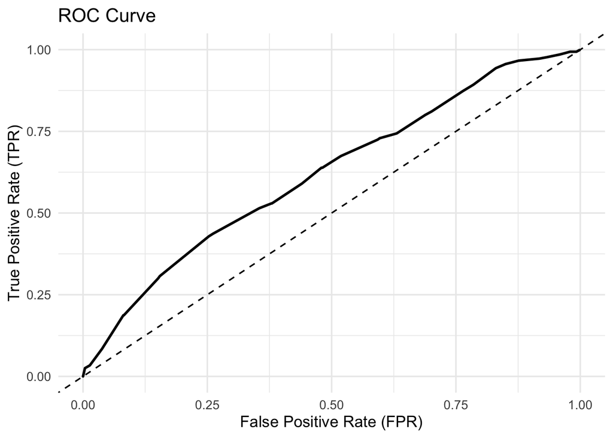

```r
# ROC curve plots tradeoff between True Positive Rate and False Positive Rate

# Build ROC object from true labels and predicted probabilities
roc_obj <- roc(response = test$click, predictor = test$p_hat, quiet = TRUE)
# False Positive Rate (x-axis) derived from specificities (1 - TNR)
fpr <- 1 - roc_obj$specificities   # False Positive Rate
# True Positive Rate (y-axis), also called recall
tpr <- roc_obj$sensitivities       # True Positive Rate

# Plot ROC curve with the random-guess diagonal as a baseline
ggplot(data = data.frame(FPR = fpr, TPR = tpr), aes(x = FPR, y = TPR)) +
  geom_line(size = 1) +
  geom_abline(slope = 1, intercept = 0, linetype = "dashed") +
  labs(title = "ROC Curve", x = "False Positive Rate (FPR)", y = "True Positive Rate (TPR)") +
  theme_minimal(base_size = 13)
```

**Questions**

# 7 AUC-ROC

```r
# AUC: single-number summary of ROC (probability a random positive ranks above a random negative)
auc_val <- as.numeric(auc(roc_obj))
round(auc_val, 3)
```

```
## [1] 0.619
```

**Questions**

- What is the maximum possible AUC? What would an AUC of 0.5 mean?

# 8 Interpretability: Odds Ratios (exp(beta))

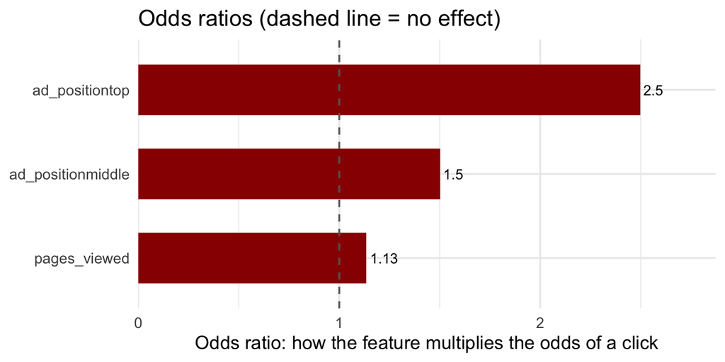

```r
# Convert log-odds coefficients into odds ratios for manager-friendly interpretation
# Drop the intercept: it is the baseline, not a feature effect
or <- exp(coef(logit_fit))
or <- or[names(or) != "(Intercept)"]

# An ordered bar chart beats a table: the dashed line at 1 means "no effect"
or_dt <- data.table(feature = names(or), odds_ratio = as.numeric(or))[order(odds_ratio)]
or_dt[, feature := factor(feature, levels = feature)]
ggplot(or_dt, aes(x = odds_ratio, y = feature)) +
  geom_col(fill = "#990000", width = 0.6) +
  geom_vline(xintercept = 1, linetype = "dashed", color = "grey40") +
  geom_text(aes(label = round(odds_ratio, 2)), hjust = -0.15, size = 3.5) +
  scale_x_continuous(expand = expansion(mult = c(0, 0.15))) +
  labs(title = "Odds ratios (dashed line = no effect)",
       x = "Odds ratio: how the feature multiplies the odds of a click",
       y = NULL) +
  theme_minimal(base_size = 13)
```

**Questions**

- If “`ad_positiontop`” has an odds ratio of ~2.5, how should we interpret this?
- Why might odds ratios be more intuitive for managers than raw coefficients?